# Publication bias and sensitivity in R

Practical · Wednesday 15:22–15:55 · FRB-CESAB training course

Author

Damien Beillouin

**By the end of this practical, you will be able to**

1. Draw and read a **contour-enhanced funnel plot**.
2. Test for **small-study effects** and **time-lag bias** in a multilevel model.
3. Run **leave-one-study-out**, **influence** and **study-quality** sensitivity analyses.
4. Build a **robustness table** for your paper.

| Time | What | Section |
| --- | --- | --- |
| 15:22 | Load data, fit the main model, funnel plot (code given) | 1 · 2 |
| 15:27 | Classic vs multilevel Egger, PET-PEESE | 3 |
| 15:37 | Sensitivity: leave-one-study-out, validity | 4 |
| 15:47 | Your turn — or the *(optional)* parts: time-lag, Cook, fail-safe N | 6 · 5 |
| 15:55 | **Debrief** with the whole group | 7 |

Sections marked *(optional)* are for those who are ahead.

# 1 Setup

Open `meta_analysis_course.Rproj` (the course kit), then `td_bias.R` (exercises with blanks `___`). Same data as in the previous practical.

```r
library(dplyr)
library(metafor)
library(ggplot2)

# In the participant pack: data_file <- "intercropping_biodiversity.csv"
ic <- read.csv(data_file)

grp <- "Pests"        # <- in section 6 you will change this word only

dat <- ic |>
  filter(functional_group == grp, !sd_missing, !zero_mean) |>
  escalc(measure = "ROM", m1i = b_mean_t, sd1i = b_sd_t, n1i = b_n_t,
         m2i = b_mean_c, sd2i = b_sd_c, n2i = b_n_c, data = _) |>
  mutate(sei = sqrt(vi),                          # standard error
         se_n = sqrt(1 / b_n_t + 1 / b_n_c),     # precision based on sample size only
         inv_n = 1 / b_n_t + 1 / b_n_c,
         year_c = year - mean(year))              # centred publication year

pct <- function(x) round(100 * (exp(x) - 1), 1)

# the main model (from the previous practical)
m <- rma.mv(yi, vi, random = ~ 1 | study_id / es_id, data = dat,
            test = "t", dfs = "contain")
pct(c(m$b, m$ci.lb, m$ci.ub))
```

```
[1] -26.9 -39.9 -11.1
```

# 2 Contour-enhanced funnel plot

**Exercise 1.** Draw the funnel with significance contours centred on **zero** (fill in one number, then spend your time on the interpretation).

```r
funnel(dat$yi, dat$vi, yaxis = "sei",
       level = c(90, 95, 99), shade = c("white", "gray75", "gray90"),
       refline = ___, legend = TRUE, xlab = "lnRR")
```

**Solution**

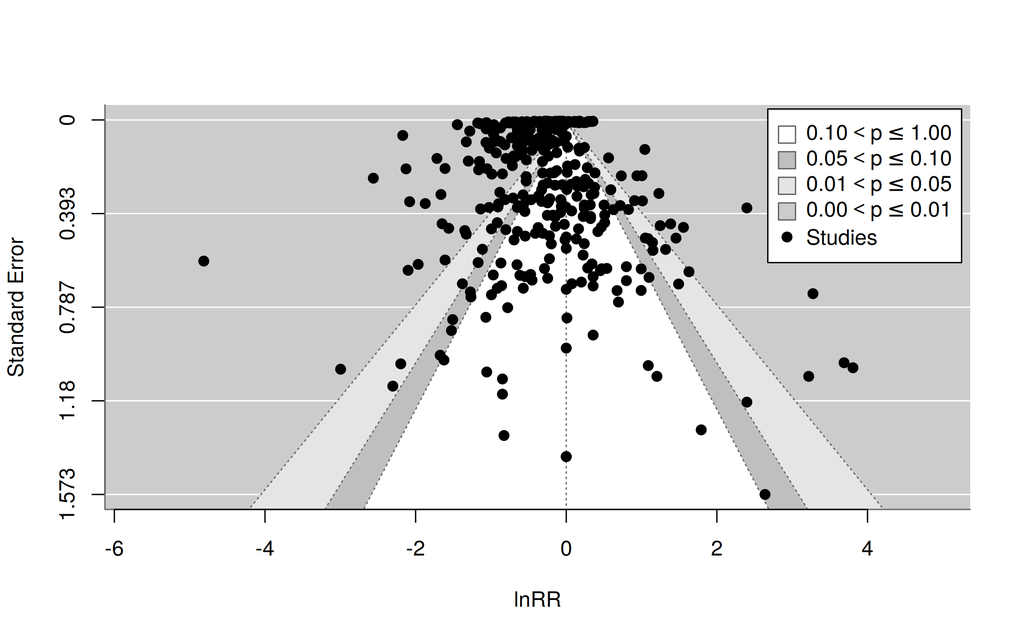

```r
funnel(dat$yi, dat$vi, yaxis = "sei",
       level = c(90, 95, 99), shade = c("white", "gray75", "gray90"),
       refline = 0, legend = TRUE, xlab = "lnRR")
```

**Interpret (2 min)**

Is the funnel symmetric? On which side, and in which zone (white = non-significant), are the imprecise comparisons?

**Answer**

The bottom of the funnel (imprecise comparisons) is roughly symmetric around 0, with points in the white (non-significant) zone on both sides: no obvious gap where suppressed non-significant results would be. At the very top, 83 comparisons have SE < 0.02 — suspiciously precise (two studies; possibly SEs recorded as SDs). Tiny variances are always worth checking at extraction.

# 3 Testing small-study effects and time-lag bias

**Exercise 2.** First the *classic* Egger test, which treats every comparison as independent:

```r
regtest(rma(yi, vi, data = dat))
```

```
Regression Test for Funnel Plot Asymmetry

Model:     mixed-effects meta-regression model
Predictor: standard error

Test for Funnel Plot Asymmetry: z =  3.5610, p = 0.0004
Limit Estimate (as sei -> 0):   b = -0.4245 (CI: -0.5092, -0.3398)
```

Now the **multilevel** version (Nakagawa et al. 2022): add a precision measure as a moderator of the main model.

**The lnRR trap**

The SE of a lnRR is computed from the means themselves, which creates an artificial correlation between effect and SE. For lnRR (and SMD), use a precision measure based on **sample size only**: `se_n` $= \sqrt{1/n_T + 1/n_C}$.

**Predict first:** will the small-study effect look stronger with `sei` or with `se_n`?

```r
pet_se <- rma.mv(yi, vi, mods = ~ sei,  random = ~ 1 | study_id / es_id,
                 data = dat, test = "t", dfs = "contain")
pet    <- rma.mv(yi, vi, mods = ~ ___, random = ~ 1 | study_id / es_id,
                 data = dat, test = "t", dfs = "contain")
round(c(slope_p_SE = pet_se$pval[2], slope_p_n = pet$pval[2]), 3)
robust(pet, cluster = study_id, clubSandwich = TRUE)   # cluster-robust check
```

**Solution**

```r
pet_se <- rma.mv(yi, vi, mods = ~ sei,  random = ~ 1 | study_id / es_id,
                 data = dat, test = "t", dfs = "contain")
pet    <- rma.mv(yi, vi, mods = ~ se_n, random = ~ 1 | study_id / es_id,
                 data = dat, test = "t", dfs = "contain")
round(c(slope_p_SE = pet_se$pval[2], slope_p_n = pet$pval[2]), 3)
```

```
slope_p_SE  slope_p_n
     0.018      0.103
```

```r
robust(pet, cluster = study_id, clubSandwich = TRUE)
```

```
Multivariate Meta-Analysis Model (k = 382; method: REML)

Variance Components:

            estim    sqrt  nlvls  fixed          factor
sigma^2.1  0.2078  0.4559     28     no        study_id
sigma^2.2  0.1893  0.4351    382     no  study_id/es_id

Test for Residual Heterogeneity:
QE(df = 380) = 100480.3902, p-val < .0001

Number of estimates:   382
Number of clusters:    28
Estimates per cluster: 1-80 (mean: 13.64, median: 8)

Test of Moderators (coefficient 2):¹
F(df1 = 1, df2 = 13.38) = 1.9876, p-val = 0.1814

Model Results:

         estimate      se¹     tval¹     df¹    pval¹    ci.lb¹    ci.ub¹
intrcpt   -0.5648  0.1699   -3.3246   16.78   0.0041   -0.9236   -0.2060   **
se_n       0.6900  0.4894    1.4098   13.38   0.1814   -0.3643    1.7443

---
Signif. codes:  0 '***' 0.001 '**' 0.01 '*' 0.05 '.' 0.1 ' ' 1

1) results based on cluster-robust inference (var-cov estimator: CR2,
   approx t/F-tests and confidence intervals, df: Satterthwaite approx)
```

With the SE, the slope looks “significant”; with the sample-size measure (and even more with cluster-robust inference) it is not: **no robust evidence of a small-study effect**. The SE-based result was largely the lnRR artefact.

**PET-PEESE: would the conclusion change if there were bias?** The intercept of `pet` estimates the effect of an infinitely large study (PET); PEESE uses `inv_n` instead. Rule (Stanley and Doucouliagos 2014): if the PET intercept is significant, report PEESE.

```r
peese <- rma.mv(yi, vi, mods = ~ inv_n, random = ~ 1 | study_id / es_id,
                data = dat, test = "t", dfs = "contain")
rbind(main  = pct(c(m$b, m$ci.lb, m$ci.ub)),
      PET   = pct(c(coef(pet)[1],   pet$ci.lb[1],   pet$ci.ub[1])),
      PEESE = pct(c(coef(peese)[1], peese$ci.lb[1], peese$ci.ub[1])))
```

```
      intrcpt
main    -26.9 -39.9 -11.1
PET     -43.2 -60.8 -17.6
PEESE   -35.6 -50.5 -16.3
```

The adjusted estimates are, if anything, stronger reductions: the conclusion does not rest on small-study effects. With strong heterogeneity, treat them as sensitivity checks, not as “the true effect”.

**Exercise 3** *(optional)*. Time-lag bias: do effects change with publication year?

```r
tl <- rma.mv(yi, vi, mods = ~ ___, random = ~ 1 | study_id / es_id,
             data = dat, test = "t", dfs = "contain")
tl
```

**Solution**

```r
tl <- rma.mv(yi, vi, mods = ~ year_c, random = ~ 1 | study_id / es_id,
             data = dat, test = "t", dfs = "contain")
tl
```

```
Multivariate Meta-Analysis Model (k = 382; method: REML)

Variance Components:

            estim    sqrt  nlvls  fixed          factor
sigma^2.1  0.2168  0.4656     28     no        study_id
sigma^2.2  0.1908  0.4368    382     no  study_id/es_id

Test for Residual Heterogeneity:
QE(df = 380) = 96736.6562, p-val < .0001

Test of Moderators (coefficient 2):
F(df1 = 1, df2 = 26) = 0.0257, p-val = 0.8740

Model Results:

         estimate      se     tval  df    pval    ci.lb    ci.ub
intrcpt   -0.3131  0.0983  -3.1839  26  0.0037  -0.5153  -0.1110  **
year_c    -0.0029  0.0181  -0.1602  26  0.8740  -0.0402   0.0344

---
Signif. codes:  0 '***' 0.001 '**' 0.01 '*' 0.05 '.' 0.1 ' ' 1
```

Slope ≈ 0 and far from significant: **no evidence** of a decline effect — but with 28 studies the test has little power.

# 4 Sensitivity analyses

**Exercise 4. Leave-one-*study*-out.** The loop is given: complete it so that each refit drops **one whole study**. (≈ 1 min to run.)

```r
ids <- unique(dat$study_id)
loo <- sapply(ids, function(i) {
  f <- rma.mv(yi, vi, random = ~ 1 | study_id / es_id,
              data = dat[dat$study_id ___ i, ], test = "t", dfs = "contain")
  c(est = f$b[1], ci.lb = f$ci.lb, ci.ub = f$ci.ub)
})
pct(range(loo["est", ]))     # range of the pooled effect
any(loo["ci.ub", ] > 0)      # does any CI cross zero?
```

**Solution**

```r
ids <- unique(dat$study_id)
loo <- sapply(ids, function(i) {
  f <- rma.mv(yi, vi, random = ~ 1 | study_id / es_id,
              data = dat[dat$study_id != i, ], test = "t", dfs = "contain")
  c(est = f$b[1], ci.lb = f$ci.lb, ci.ub = f$ci.ub)
})
pct(range(loo["est", ]))
```

```
[1] -29.3 -22.9
```

```r
any(loo["ci.ub", ] > 0)
```

```
[1] FALSE
```

We leave out **studies**, not rows: rows of a study are not independent.

**Exercise 5** *(optional)*. **Influence** (Cook’s distance, by study) (Viechtbauer and Cheung 2010):

```r
cd <- cooks.distance(m, cluster = dat$___)
sort(round(cd, 2), decreasing = TRUE)[1:5]
```

**Solution**

```r
cd <- cooks.distance(m, cluster = dat$study_id)
sort(round(cd, 2), decreasing = TRUE)[1:5]
```

```
1323  742  522  763  645
0.32 0.14 0.11 0.11 0.07
```

**Exercise 6. Study quality.** How many comparisons could not be appraised (`NA`)? Then refit the model with only the comparisons that meet all validity criteria (`validity_biodiv == 1`, coded by the authors of the database), and test validity as a **moderator** (comparing two CIs by eye is not a test).

```r
m_val <- rma.mv(yi, vi, random = ~ 1 | study_id / es_id,
                data = filter(dat, validity_biodiv == ___), test = "t", dfs = "contain")
pct(c(m_val$b, m_val$ci.lb, m_val$ci.ub))
```

**Solution**

```r
m_val <- rma.mv(yi, vi, random = ~ 1 | study_id / es_id,
                data = filter(dat, validity_biodiv == 1), test = "t", dfs = "contain")
pct(c(m_val$b, m_val$ci.lb, m_val$ci.ub))
```

```
[1] -27.4 -39.1 -13.4
```

```r
m_val$s.nlevels[1]                  # number of studies left
```

```
[1] 13
```

```r
sum(is.na(dat$validity_biodiv))     # comparisons that could not be appraised
```

```
[1] 130
```

```r
m_vmod <- rma.mv(yi, vi, mods = ~ factor(validity_biodiv), random = ~ 1 | study_id / es_id,
                 data = dat, test = "t", dfs = "contain")
m_vmod$pval[2]                      # does validity change the effect?
```

```
[1] 0.7367947
```

Same estimate, validity does not moderate the effect for pests. Note that a third of the comparisons could not be appraised: report it.

# 5 *(optional)* Fail-safe N: why not

```r
fsn(yi, vi, data = dat)
```

```
Fail-safe N Calculation Using the Rosenthal Approach

Observed Significance Level: <.0001
Target Significance Level:   0.05

Fail-safe N: 4098124
```

**Discuss**

Millions of “missing” studies would be needed to cancel the effect. Does that make you confident? What does this number assume about the missing studies, about heterogeneity and about dependence?

**Answer**

It assumes missing studies have exactly zero effect, ignores heterogeneity and the dependence between comparisons, and says nothing about the size of any bias. It is almost always “reassuring”, hence uninformative: **do not report it** (Nakagawa et al. 2022).

**(optional) Trim-and-fill, as a sensitivity analysis only**

Trim-and-fill cannot handle dependent effect sizes; apply it to **one aggregated effect per study** (here assuming ρ = 0.5 within studies, and a common effect within each study — a strong simplification):

```r
agg <- aggregate(dat, cluster = study_id, rho = 0.5)
tf  <- trimfill(rma(yi, vi, data = agg))
tf
```

```
Estimated number of missing studies on the right side: 0 (SE = 2.6471)

Random-Effects Model (k = 28; tau^2 estimator: REML)

tau^2 (estimated amount of total heterogeneity): 0.7345 (SE = 0.2107)
tau (square root of estimated tau^2 value):      0.8570
I^2 (total heterogeneity / total variability):   99.98%
H^2 (total variability / sampling variability):  5517.89

Test for Heterogeneity:
Q(df = 27) = 20289.3510, p-val < .0001

Model Results:

estimate      se     zval    pval    ci.lb    ci.ub
 -0.4634  0.1665  -2.7826  0.0054  -0.7898  -0.1370  **

---
Signif. codes:  0 '***' 0.001 '**' 0.01 '*' 0.05 '.' 0.1 ' ' 1
```

Here no study is imputed. Report it, if at all, as a sensitivity check — never as “the corrected effect”.

# 6 Your turn: natural enemies

Go back to section 1, set `grp <- "Natural enemies"`, and rerun **sections 1–3 only** (skip the slow leave-one-out). Is there a small-study effect with `se_n`? Would bias explain the (small, non-significant) increase? Then run Exercise 6: does validity matter here?

**Solution**

```r
ne <- ic |>
  filter(functional_group == "Natural enemies", !sd_missing, !zero_mean) |>
  escalc(measure = "ROM", m1i = b_mean_t, sd1i = b_sd_t, n1i = b_n_t,
         m2i = b_mean_c, sd2i = b_sd_c, n2i = b_n_c, data = _) |>
  mutate(se_n = sqrt(1 / b_n_t + 1 / b_n_c))
f_ne <- function(mods) rma.mv(yi, vi, mods = mods, random = ~ 1 | study_id / es_id,
                              data = ne, test = "t", dfs = "contain")
m_ne   <- f_ne(~ 1)
pet_ne <- f_ne(~ se_n)
val_ne <- f_ne(~ factor(validity_biodiv))
rbind(main = pct(c(m_ne$b, m_ne$ci.lb, m_ne$ci.ub)),
      PET  = pct(c(coef(pet_ne)[1], pet_ne$ci.lb[1], pet_ne$ci.ub[1])))
```

```
     intrcpt
main     8.3  -9.1 29.0
PET    -10.4 -35.0 23.3
```

```r
c(slope_p = pet_ne$pval[2], validity_p = val_ne$pval[2])
```

```
   slope_p validity_p
0.13048793 0.01407015
```

```r
coef(val_ne)
```

```
                 intrcpt factor(validity_biodiv)1
             -0.07274506               0.30890264
```

The increase of natural enemies is small and not significant; the small-study slope is not significant with `se_n`, and the PET estimate is close to zero: the evidence is **inconclusive**, whatever the bias. But **validity matters**: comparisons meeting all validity criteria show a clearly **larger increase** of natural enemies (about +27%) than the others (about −7%) — poorly designed comparisons may be masking a real benefit. That is a moderator — the topic of the next session.

# 7 Debrief: your robustness table

Fill it in for pests — this is what reviewers expect:

| Analysis | Estimate [95% CI] | Conclusion changes? |
| --- | --- | --- |
| Main multilevel model |  |  |
| Only valid comparisons |  |  |
| Leave-one-study-out (range) |  |  |
| Small-study effect (`se_n`) / PEESE |  |  |
| Time-lag (slope) |  |  |

1. Bias is best **prevented** by the search, not corrected by statistics.
2. **Asymmetry ≠ publication bias**: read the direction; use contour-enhanced funnels.
3. With several effect sizes per study, use **multilevel** tests — for lnRR with a **sample-size-based** precision; drop fail-safe N; trim-and-fill only as sensitivity.
4. Report all sensitivity analyses in a **robustness table**.

**Next session (16:15):** *explaining* heterogeneity — meta-regression. (The multilevel Egger test you just ran was already a meta-regression!)

## Going further in the online notebook

- [Publication bias and sensitivity](https://literaturesynthesis.github.io/notebook/chapters/publication-bias.html)
- [Data extraction and critical appraisal](https://literaturesynthesis.github.io/notebook/chapters/extraction-appraisal.html)
- [Reading a meta-analysis critically](https://literaturesynthesis.github.io/notebook/chapters/critical-reading.html)

## 7.1 References

Nakagawa, S., M. Lagisz, M. D. Jennions, J. Koricheva, D. W. A. Noble, T. H. Parker, A. Sánchez-Tójar, Y. Yang, and R. E. O’Dea. 2022. [Methods for testing publication bias in ecological and evolutionary meta-analyses](https://doi.org/10.1111/2041-210X.13724). Methods in Ecology and Evolution 13:4–21.

Stanley, T. D., and H. Doucouliagos. 2014. [Meta-regression approximations to reduce publication selection bias](https://doi.org/10.1002/jrsm.1095). Research Synthesis Methods 5:60–78.

Viechtbauer, W., and M. W.-L. Cheung. 2010. [Outlier and influence diagnostics for meta-analysis](https://doi.org/10.1002/jrsm.11). Research Synthesis Methods 1:112–125.